# Introduction to Linear Algebra – 第六章(4)：正定矩阵与奇异值分解

bourneli

2016年12月

正定矩阵是一种特殊的对称的矩阵，很多应用中都会涉及正定矩阵的相关性质。正定矩阵比较有趣的一点是，它可以将线性代数中很**多重要的概念串联起来**，形成一个整体。SVD是正定矩阵的一个主要应用，它可以将任意矩阵分解成正交矩阵和对角矩阵的乘积，可以用于数据压缩。

## 正定矩阵性质

**对称**矩阵$A$具有下面5个性质中的一个，那么它就具备了剩下的其他性质，并且被称之为**正定矩阵**:

1. 所有主元大于0
2. 所有左上行列式大于0
3. 所有特征值大于0
4. $x^TAx \gt 0, x \ne 0$
5. $A=R^TR$并且R的列线性独立

## 例子

已知矩阵$A = \begin{bmatrix} 2 & 1 \\ 1 & 2 \end{bmatrix}$。计算主元，得到$rref(A)=\begin{bmatrix} 2 & 1 \\ 0 & \frac{3}{2} \end{bmatrix}$。可以轻松计算特征值，左上行列式。

二次形式展开 $\begin{bmatrix} x_1 & x_2 \end{bmatrix} \begin{bmatrix} 2 & 1 \\ 1 & 2 \end{bmatrix} \begin{bmatrix} x_1 \\ x_2 \end{bmatrix} = 2(x_1^2+x_1x_2+x_2^2)= 2(x_1+\frac{1}{2}x_2)^2+\frac{3}{2}x_2^2 > 0$

$A=LDL^T$分解,然后变成R

$A=\begin{bmatrix} 2 & 1 \\ 1 & 2 \end{bmatrix} =\begin{bmatrix} 1 & 0 \\ \frac{1}{2} & 1 \end{bmatrix} \begin{bmatrix} 2 & 0 \\ 0 & \frac{3}{2} \end{bmatrix} \begin{bmatrix} 1 & \frac{1}{2} \\ 0 & 1 \end{bmatrix} =\begin{bmatrix} 1 & 0 \\ \frac{1}{2} & 1 \end{bmatrix} \begin{bmatrix} \sqrt{2} & 0 \\ 0 & \sqrt{\frac{3}{2}} \end{bmatrix} \begin{bmatrix} \sqrt{2} & 0 \\ 0 & \sqrt{\frac{3}{2}} \end{bmatrix} \begin{bmatrix} 1 & \frac{1}{2} \\ 0 & 1 \end{bmatrix}$

2乘2矩阵，完全符合上面的性质。

## 正定矩阵性质证明

上面有5个性质，如果每两个互相证明，那么需要证明20个定理，非常繁琐。其实，可以用**图**的角度看待这个问题，将每个性质看作图的顶点，如果性质之间具有推导特性，看作一条有向边。只要任意一个点出发，都可以到达其他顶点，那么问题就解决了，并且需要证明的定理也不需要20个。经过观察，可以得到下面的推导图，

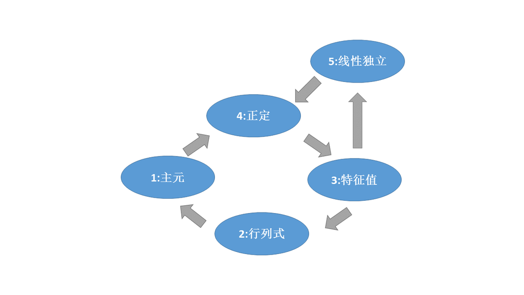

根据上面的推导图，现在只需要证明6个定理，即可达到目的，下面逐个证明。

### 证明：4 $\Rightarrow$ 3

**命题** 若对称矩阵A有性质$x^TAx \gt 0, x \ne 0$，证明A的所有特征值均为正数。

**证明**

A对称，那么其必然可以对角化，有$A=Q \Lambda Q^T$,且将正定性质代入，具有$x^TQ \Lambda Q^Tx \gt 0$，其中$\Lambda$是对角矩阵，对角元素为$\lambda_1, \cdots, \lambda_n$。令$y = Q^Tx=\begin{bmatrix}y_1 && \cdots && y_n\end{bmatrix}^T$。所以，最后有

$y\Lambda y^T>0 \Rightarrow \sum_{i=1}^{n}\lambda_i y_i^2 > 0$

上述不等式需要对任意不等于0向量的x成立，由于$Q^T$是标准正交矩阵，也就是对任意不等于0向量的y成立，所以$\lambda_i > 0$必须横成立。

**证毕**

### 证明：3 $\Rightarrow$ 5

**命题** 若对称矩阵A所有特征值大于0，证明存在矩阵R，其列线性独立，且$A=R^TR$。

**证明**

A对称，所以有$A=Q \Lambda Q^T$。因为条件$\lambda_i > 0$，所以有$A=Q \Lambda^{\frac{1}{2}} (\Lambda^{\frac{1}{2}})^T Q^T$，令$R=(Q \Lambda^{\frac{1}{2}})^T$,且$R^{-1}=Q\Lambda^{-\frac{1}{2}}$，那么有R可逆且$A=R^TR$。

**证毕**

### 证明: 5 $\Rightarrow$ 4

**命题** 对称矩阵A有$A=R^TR$并且R的列线性独立，证明 $x^TAx \gt 0, x \ne 0$

**证明**

因为R列线性独立，$x\ne 0$，所以$Rx \ne 0$。

直接按照条件展开$x^TAx=x^TR^TRx=(\|Rx\|)^2>0$恒成立。

**证毕**

### 证明：3 $\Rightarrow$ 2

**命题** 对称矩阵A的所有特征值大于0，证明A的所有左上行列式大于0

**证明**

因为A所有特征值$\lambda_i \gt 0$，所以有$\|A\| = \prod_{i=1}^{n}\lambda_i \gt 0$。

假设$A_k$是矩阵A保留左上角k行和k列。因为对任意$x \ne 0$，均有$x^TAx \gt 0$,所以对于特殊形式的$x=(x_1,x_2,\cdots,x_k,0,\cdots,0)\ne 0, k = 1,2,\cdots,n$仍然成立，则$A_k$与A有如下关系

$\begin{align} 0 <& (x_1,x_2,\cdots,x_k,0,\cdots,0)A(x_1,x_2,\cdots,x_k,0,\cdots,0)^T \\ =& (x_1,x_2,\cdots,x_k) A_k (x_1,x_2,\cdots,x_k) \end{align}$

所以$A_k$所有特征值大于0（利用$4 \Rightarrow 3$），所以$\|A_k\| \gt 0$。

**证毕**

### 证明：2 $\Rightarrow$ 1

**命题** 对称矩阵A所有左上行列式大于0,证明A的所有主元大于0

**证明**

因为$\|A_k\|>0$，所以A可逆。那么，可以只通过基础消元（特征值不变），而不需要基础换行或基础乘法（这些导致特征值变化），将A化简为只有$主对角线$的矩阵，此时对角线上的元素就是主元$p_i$，并且此过程做上角行列式保持不变。所以有$\|A_k\|=\prod_{i=1}^kp_i,\|A_{k-1}\|=\prod_{i=1}^{k-1}p_i$,推导出$p_k=\frac{\|A_k\|}{\|A_{k-1}\|}>0$。

**证毕**

### 证明：1 $\Rightarrow$ 4

**命题** 对称矩阵A所有主元大于0，证明$x^TAx > 0,x \ne 0$

**证明**

使用LDU分解，由于A对称，所以$A=LDL^T$，其中D是对角矩阵，且每个元素$p_i$是A的主元。代入x，有$x^TLDL^Tx$。令$y=L^Tx=(y_1,y_2,\cdots,y_n)$。所以$x^TLDL^Tx=y^TDy=\sum_{i=1}^np_iy_i^2>0$。

**证毕**

至此，所以必要的定理已经证明完成，得到了完成的证明图，最终的问题得到了证实。

## 正定应用

- 假设C是正定，且A列线性独立，证明$A^TCA$正定，工程应用中的重要定理。

证明：$R=\Lambda^{\frac{1}{2}}QA$,易证明R线性独立。因为只有x=0时，$RX=0$才成立，否则不行。

- 二元矩阵中，正定的二次型是椭圆形。
- 很多概率模型需要其中的矩阵正定。

## 奇异值分解SVD

假设矩阵A为任意维度，A的秩为$r$，如果不为方正，那么自然是得不到特征值和特征向量的。但是$A^TA$与$AA^T$却是对称的，而且根据正定性，它们是半正定矩阵。所以，可以计算相关的特征值和特征向量。那么，这两个矩阵的特征向量是否有什么关系呢？

### 大胆假设

我们来做一些大胆的设想，假设下面条件统统成立：

1. $v_1,\cdots,v_r \in R(A)$,$u_1,\cdots,u_r \in C(A)$
2. $v_1,\cdots.v_r是正交单位矩阵,u_1,\cdots,u_r是正交单位矩阵$
3. $Av_1 = \rho_1u_1, Av_2 = \rho_2u_2,\cdots , Av_r = \rho_ru_r$
4. $\rho_i > 0, i = 1,2,\cdots,r$

读者可能不禁要想，对于任意矩阵A，这种假设是不是太过苛刻！先不管那么多，假设成立，可以得到

$A\begin{bmatrix}v_1 & \cdots & v_r\end{bmatrix} = \begin{bmatrix}u_1 & \cdots & u_r\end{bmatrix} \begin{bmatrix} \sigma_1 \\ &\ddots & \\ &&\sigma_r \end{bmatrix}$

由于$v_i,u_i$均是正交的，所以可以使用Gram-Schimidt方法将其扩展到整个行空间和列空间，得到下面

$A\underbrace{\begin{bmatrix}v_1 & \cdots & v_r & v_{r+1} & \cdots & v_n\end{bmatrix}}_V = \underbrace{\begin{bmatrix}u_1 & \cdots & u_r & u_{r+1} & \cdots & u_m \end{bmatrix}}_U \underbrace{ \begin{bmatrix} \sigma_1 \\ & \ddots \\ && \sigma_r \\ &&& 0 \\ &&&& \ddots \\ &&&&& 0 \\ \end{bmatrix} }_{\Sigma}$

简化上面的表达式

$AV = U\Sigma \Rightarrow A = U\Sigma V^T$

也就是说，如果矩阵A满足上面这些条件，就可以将A分解成两个正交矩阵和一个对角矩阵，是不是非常优美！由于$\Sigma$后面对角线元素都为0，所以可以进一步简化：

$\underbrace{A}_{m \times n} = \underbrace{U_r}_{m \times r} \underbrace{\Sigma_r}_{r \times r} \underbrace{V^T_r}_{r \times n}$

$U_r$是U保留前r列，$V^T_r$是$V^T$保留前r行，$\Sigma_r$是保留前r行与r列。

### 小心求证

首先从$A^TA$开始，由于半正定性，所以可以将其特征值写成如下形式

$A^TAv_i=\sigma_i^2v_i \qquad (1)$

由$A^TA$半正定性，可得$v_i$标准正交，且令$\sigma_i \gt 0(i = 1,2, \cdots, r$)称之为**奇异值**(注意:不要与特征值混淆)。对公式(1)两边乘以$v_i^T$得到

$v_i^TA^TAv_i=v_i^T\sigma_i^2v_i \Rightarrow \|Av_i\|^2 = \sigma_i^2 \Rightarrow \sigma_i = \|Av_i\| \qquad (2)$

从公式(2)可以了解到，奇异值$\sigma_i$是$A^TA$单位特征向量$v_i$在矩阵A列空间的投影向量的模长（很绕口，看看就好，不用太在意）。然后，继续对公式(1)两边乘以A,构造出$AA^T$

$AA^TAv_i=A\sigma_i^2v_i \Rightarrow AA^T(Av_i)=\sigma_i^2(Av_i) \qquad (3)$

线性代数中有很多重要证明利用了括号变化，上面又是一个重要的例子。根据公式(3),可以发现$AA^T$与$A^TA$具有相同的特征值$\sigma_i^2$。并且特征向量具有关系，令$u_i$是$AA^T$的特征向量，明显有$u_i$正交，且由公式(3),$u_i=Av_i$。但是正交特征矩阵一般需要为单位矩阵，而且由公式(1)可以容易得到模长，所以最终令$u_i=\frac{Av_i}{\sigma_i}$。上面的假设得到了证明。

事实证明，上面的假设并不苛刻，对于任意A都可以找到这些向量和奇异值将其分解，不得不佩服发现SVD的数学家们。

### 计算策略

由于$A^TA$与$AA^T$的**特征值相同**，计算策略显而易见，计算维度较小的那个矩阵的特征值。因为特征值的复杂度是$O(n^3)$,n是矩阵阵的行数，当行数很高时，根本无法计算。spark中的SVD也是按这种策略实现。

### 奇异值的权重

奇异值都是大于0的实数，可以认为是权重，所以将奇异值按照从大到小的方式延对角线排列，可以得到唯一的分解。将SVD分解按代数形式展开，如下

$A = \begin{bmatrix}u_1 & \cdots & u_r\end{bmatrix} \begin{bmatrix} \sigma_1 \\ &\ddots & \\ &&\sigma_r \end{bmatrix} \begin{bmatrix}v_1^T \\ \vdots \\ v_r^T\end{bmatrix} = \sum_{i=1}^{r}\sigma_i u_i v_i^T$

A是r个秩为1的矩阵的线性组合，且每个矩阵室由单位向量乘法构成模，奇异值是系数。如果最后的奇异值比较小，可以忽略，对A的整体影响比较小，这样可以做有损压缩。